# История и перспективы приватизации в Украине

##### Рис.2. Количество приватизированных предприятий по группам (1992-2015 гг)

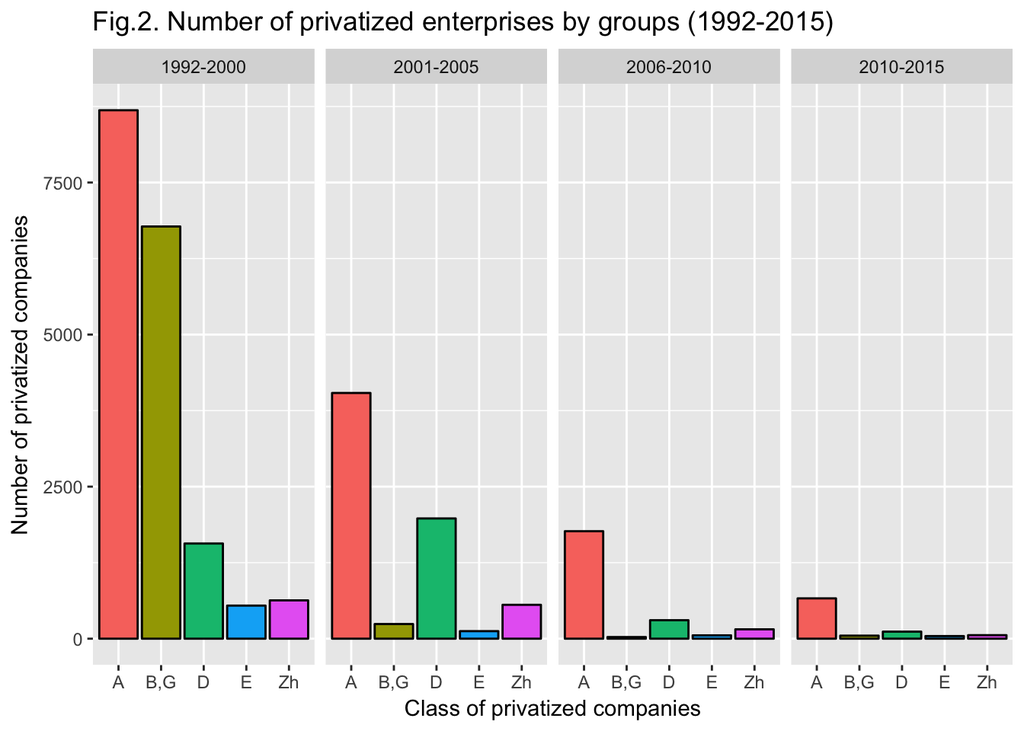

```r
phase1 <- count_priv_companies(1993:2000)
phase2 <- count_priv_companies(2001:2005)
phase3 <- count_priv_companies(2006:2010)
phase4 <- count_priv_companies(2010:2015)
phase1$years <- as.factor(c("1992-2000", "1992-2000", "1992-2000", "1992-2000", "1992-2000"))
phase2$years <- as.factor(c("2001-2005", "2001-2005", "2001-2005", "2001-2005", "2001-2005"))
phase3$years <- as.factor(c("2006-2010", "2006-2010", "2006-2010", "2006-2010", "2006-2010"))
phase4$years <- as.factor(c("2010-2015", "2010-2015", "2010-2015", "2010-2015", "2010-2015"))
all_phases <- rbind(phase1, phase2, phase3, phase4)

ggplot(data = all_phases, aes(x = Companies.class, y = Number.of.privatized.companies,
                                         fill = Companies.class ))+
        geom_bar(colour="black", stat = "identity")+
        guides(fill=FALSE)+
        xlab("Class of privatized companies")+
        ylab("Number of privatized companies")+
        ggtitle("Fig.2. Number of privatized enterprises by groups (1992-2015)")+
        facet_grid(.~years, scales = "free")
```

```r
all_phases
```

```
##    Companies.class Number.of.privatized.companies     years
## 1                A                           8688 1992-2000
## 2              B,G                           6777 1992-2000
## 3                D                           1565 1992-2000
## 4                E                            544 1992-2000
## 5               Zh                            630 1992-2000
## 6                A                           4040 2001-2005
## 7              B,G                            241 2001-2005
## 8                D                           1977 2001-2005
## 9                E                            124 2001-2005
## 10              Zh                            557 2001-2005
## 11               A                           1767 2006-2010
## 12             B,G                             27 2006-2010
## 13               D                            304 2006-2010
## 14               E                             55 2006-2010
## 15              Zh                            154 2006-2010
## 16               A                            663 2010-2015
## 17             B,G                             50 2010-2015
## 18               D                            116 2010-2015
## 19               E                             43 2010-2015
## 20              Zh                             58 2010-2015
```

Поскольку практически все предприятия групп В и Г были приватизированы до 2005 (7 тыс.) то структура приватизированных в этот период предприятий по отраслям промышленности даст нам общее понимание того, какие именно сектора реальной экономики государство передало в частные руки. (Рис.3) Как мы видим, основными отраслями промышленности, которых коснулась приватизация, стали машиностроение, строительство, пищевая и транспортная промышленность.

##### Рис.3. Приватизированные предприятия групп В,Г по отраслям промышленности на 01.01.2005 г.[^3]

```r
Priv_economic_activity
```

```
##          economic.activity number.of.privatized.companies.on.01.01.2005
## 1         Mashine building                                         1698
## 2             Construction                                         1355
## 3            Food industry                                         1167
## 4       Transport industry                                         1092
## 5   Construction Materials                                          516
## 6           Light industry                                          391
## 7  Woodprocessing industry                                          241
## 8        Chemical industry                                          156
## 9       Ferrous metallurgy                                          123
## 10           Fuel industry                                           41
## 11       Power engineering                                           38
```

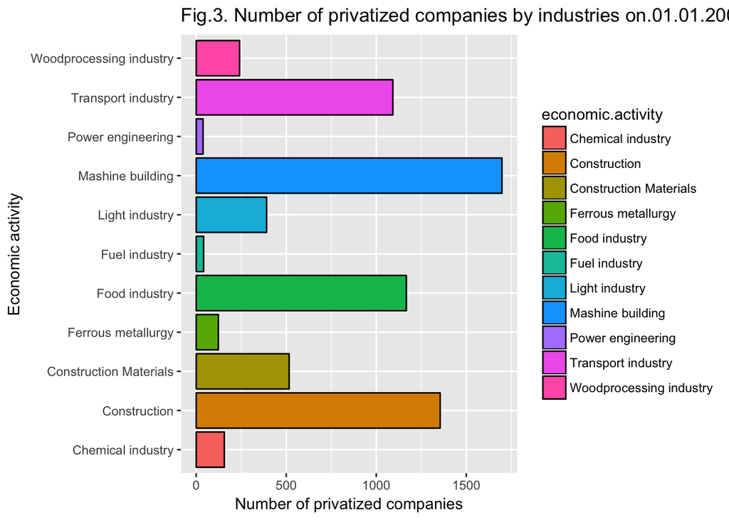

```r
ggplot(data = Priv_economic_activity, aes(x = economic.activity, y = number.of.privatized.companies.on.01.01.2005,
                                         fill = economic.activity))+
        geom_bar(colour="black", stat = "identity")+
        coord_flip()+
        xlab("Economic activity")+
        ylab("Number of privatized companies")+
        ggtitle("Fig.3. Number of privatized companies by industries on.01.01.2005")
```

Об ударных темпах приватизации так же говорит и тот факт, что еще в 2001 году количество государственных предприятий составляло 5% от общего числа предприятий Украины, а уже в 2014 – только 2% (около 6 тыс.), Из них более 2 тыс. относились к предприятиям военно-промышленного комплекса и инфраструктурным предприятиям – отраслям промышленности, пока практически избежавшим приватизации.[^4] (рис.4).

##### Рис. 4. Количество государственных и частных предприятий Украины по годам[^5]

```r
OwnershipData
```

```
##    year enterprise.ownership number.of.enterprices
## 1  2001                state                  9965
## 2  2006                state                  7562
## 3  2007                state                  7359
## 4  2008                state                  7213
## 5  2009                state                  6975
## 6  2010                state                  6801
## 7  2011                state                  6661
## 8  2012                state                  6512
## 9  2013                state                  6075
## 10 2014                state                  5933
## 11 2001              private                192168
## 12 2006              private                248211
## 13 2007              private                258536
## 14 2008              private                270331
## 15 2009              private                278574
## 16 2010              private                283697
## 17 2011              private                285821
## 18 2012              private                283911
## 19 2013              private                280073
## 20 2014              private                278227
```

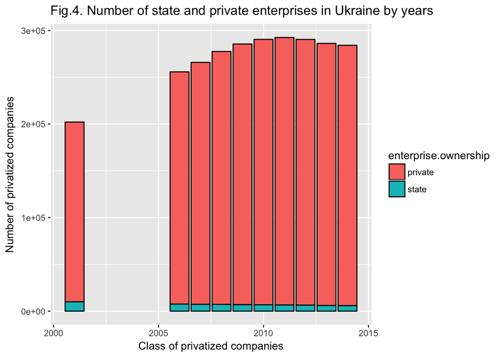

```r
ggplot(data = OwnershipData, aes(x = year, y = number.of.enterprices,
                                         fill = enterprise.ownership ))+
        geom_bar(colour="black", stat = "identity")+
        xlab("Class of privatized companies")+
        ylab("Number of privatized companies")+
        ggtitle("Fig.4. Number of state and private enterprises in Ukraine by years")
```

Даже Европейский Союз в лице Европейского Банка Реконструкции и Развития довольно высоко оценил эти успехи Украины на пути передачи государственного имущества в более эффективные частные руки, как обязательного условия успешного экономического развития. В своем ежегодном исследовании, аналитики Банка выставляют индексовый показатель (от «1» до «5»), оценивающий уровень приватизации в стране для крупных и мелких предприятий[^6]:

**Приватизации крупных предприятий:**

«1» - Низкий уровень приватизации. «2» - Всесторонняя схема почти готова к внедрению; некоторые продажи завершены. «3» - Более 25 процентов крупных предприятий перешли в частные руки или в процессе приватизации. «4» - Более 50 процентов государственных предприятий и сельскохозяйственных активов в частной собственности. «4+» - Стандарты и показатели типичны для передовых промышленно развитых стран: более 75 процентов активов предприятий в частной собственности.

**Приватизация мелких предприятий:**

«1» - низкий уровень приватизации. «2» Значительная доля приватизирована. «3» Комплексная программа почти готова к реализации. «4» Полная приватизация малых компаний с торгуемых права собственности. «4+» Стандарты и показатели характерны для развитых индустриальных экономик: нет государственной собственности малых предприятий;

По этому комплексному оценочному показателю, начав вместе с другими странами бывшего СССР с «1» в 1990 году, уже к 2014 году Украина поднялась к «3» по приватизации крупных предприятий и к «4» по приватизации малых предприятий, значительно обогнав Беларусь, и совсем немного отстав от Латвии и Литвы, которые прожили эти годы в «европейской семье». (см.рис.5)

##### Рис.5. Приватизация в Украине, Беларуси, Латвии и Литве. Комплексная оценка ЕБРР по годам.

```r
PrivIndexEBRD
```

```
##    year   country privatization.class privatization.index
## 1  1990   Ukraine                 big                 1.0
## 2  2014   Ukraine                 big                 3.0
## 3  1990   Ukraine               small                 1.0
## 4  2014   Ukraine               small                 4.0
## 5  1990   Belarus                 big                 1.0
## 6  2014   Belarus                 big                 1.7
## 7  1990   Belarus               small                 1.0
## 8  2014   Belarus               small                 2.3
## 9  1990    Latvia                 big                 1.0
## 10 2014    Latvia                 big                 3.7
## 11 1990    Latvia               small                 1.0
## 12 2014    Latvia               small                 4.0
## 13 1990 Lithuania                 big                 1.0
## 14 2014 Lithuania                 big                 4.0
## 15 1990 Lithuania               small                 1.0
## 16 2014 Lithuania               small                 4.3
```

[figure not shown]

```r
ggplot(data = PrivIndexEBRD, aes(x = country, y = privatization.index,
                                         fill = country ))+
        geom_bar(colour="black", stat = "identity")+
        xlab("Countries")+
        ylab("EBRD privatization index")+
        ggtitle("Fig.5. EBRD's assessment of the level of privatization by years.")+
        facet_grid(privatization.class~year)
```

К каким результатам в экономике Украины, в совокупности с другими факторами, привело такое структурное изменение, как смена собственника с государственного на частного? Как отразилось на поступлениях в государственный бюджет? Стало ли подспорьем в борьбе с безработицей и бедностью? Подстегнуло ли к развитию промышленности?

# ПРИВАТИЗАЦИЯ КАК ИСТОЧНИК ПОПОЛНЕНИЯ ГОСУДАРСТВЕННОГО БЮДЖЕТА УКРАИНЫ?

Считается, что поступления в государственный бюджет от приватизации обычно «значительные», и являются важной статьей формирования доходной части бюджета. Уменьшение поступлений от приватизации в процентном соотношении за предыдущий отчетный период воспринимаются как «большая катастрофа», а увеличение – как «большое достижение», и всерьез и долго обсуждаются журналистами и экспертами в средствах массовой информации. Любознательный слушатель прямо сейчас может забить в поисковике словосочетание «поступления от приватизации в государственный бюджет» и убедиться, что это правда. Следует отметить, что Фонд Госимущества Украины, в своих ежегодных отчетах предпочитает публиковать график ежегодных поступлений в бюджет от приватизации по «накопительному итогу», т.е. прибавляя к отчетному периоду весь предыдущий «запас». В результате получается очень оптимистичная картина (Рис.6)[^7] некоего «стабильного роста», из которой следует, что всего за 1992-2015 гг от приватизации в бюджет страны поступило 63 млрд.грн.

##### Рис. 6. Поступления в государственный бюджет Украины от приватизации 1992-2015 гг по накопительному итогу (млн.грн.)

```r
BudgetPriv_comulative
```

```
##         Year Million.UAH
## 1  1992-1999      1202.6
## 2       2000      3278.1
## 3       2001      5410.1
## 4       2002      5986.2
## 5       2003      8001.9
## 6       2004     17416.8
## 7       2005     38116.0
## 8       2006     36638.9
## 9       2007     41097.2
## 10      2008     41577.9
## 11      2009     42381.5
## 12      2010     43478.6
## 13      2011     54959.0
## 14      2012     61722.3
## 15      2013     63263.5
## 16      2014     63669.1
## 17      2015     63820.6
```

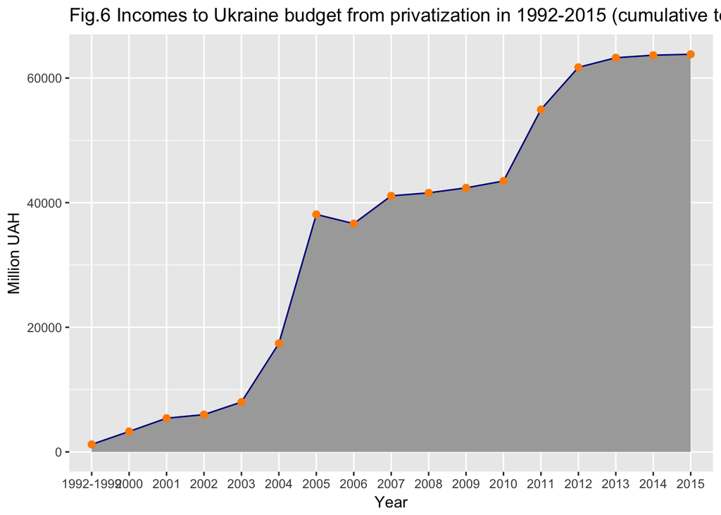

```r
ggplot(data = BudgetPriv_comulative, aes(x = Year, y = Million.UAH, group = 1))+
        geom_area(stat = "identity", fill = "darkgray")+
        geom_line(colour="darkblue", size = 0.5)+
        geom_point(colour="darkorange", size = 2)+
        xlab("Year")+
        ylab("Million UAH")+
        ggtitle("Fig.6 Incomes to Ukraine budget from privatization in 1992-2015 (cumulative total)")
```

Однако, если посмотреть на реальные поступления в бюджет, не приплюсовывая «по-популистски» финансовые результаты всех предыдущих отчетных периодов к текущему, получится совершенно другая картина (рис.7)[^8].